# Plotting for metric learning

```r
library(tidyverse)
library(dimRed)
library(reticulate)
library(here)
library(viridis)
library(hdrcde)
library(igraph)
library(matrixcalc)
library(akima)
library(car)
Jmisc::sourceAll(here::here("R/sources"))
set.seed(123)
```

# Metric learning

## Smart meter data for one household

```r
# load(here::here("data/spdemand_3639id336tow.rda"))
# nid <- 1
# ntow <- 336
#
# train <- spdemand %>%
#   lazy_dt() %>%
#   filter(tow <= ntow,
#          # id <= sort(unique(spdemand[,id]))[nid],
#          id == 1003) %>%
#   dplyr::select(-id, -tow) %>%
#   data.table::as.data.table()
train <- readRDS(here::here("data/spdemand_1id336tow_train.rds"))
```

## Radius searching with k-d trees

```r
# Parameters fixed
x <- train
N <- nrow(train)
s <- 2
k <- 20
method <- "annIsomap"
annmethod <- "kdtree"
distance <- "euclidean"
treetype <- "kd"
searchtype <- "radius" # change searchtype for radius search based on `radius`, or KNN search based on `k`
radius <- .4 # the bandwidth parameter, \sqrt(\elsilon), as in algorithm
```

## The metric learning algorithm

```r
metric_isomap <- metricML(x, s = s, k = k, radius = radius, method = method, annmethod = annmethod, eps = 0, distance = distance, treetype = treetype, searchtype = searchtype, invert.h = TRUE)
summary(metric_isomap)
```

```
##                Length Class     Mode
## embedding         672 -none-    numeric
## rmetric          1344 -none-    numeric
## weighted_graph     10 igraph    list
## adj_matrix     112896 dgCMatrix S4
## laplacian      112896 dgCMatrix S4
```

The function `metricML()` returns a list of

- the embedding coordinates `embedding` of $N \times s$
- the embedding metric `rmetric` for each point $p \in x$ as an array. By default, `invert.h = TRUE` returns the inverse of Riemannian metric.
- the weighted neighborhood graph as an `igraph` object `weighted_graph`
- the sparse adjacency matrix from the graph `adj_matrix`
- the graph laplacian matrix `laplacian`

# Embedding plot

```r
# Embedding plot of metricML() output for electricity data
plot.embedding <- function(x) {
  fn <- x$embedding

  todcolor <- colorspace::scale_color_continuous_sequential(
    palette = "viridis",
    breaks = c(0, 12, 24, 36, 48),
    labels=c("00:00", "06:00", "12:00", "18:00", "24:00"),
    name="Time of day",
    guide=guide_colorbar(barwidth = 10))

  p <- fn %>%
    cbind(tod = rep(1:48, N / 48)) %>%
    as_tibble() %>%
    ggplot(aes(x = E1, y = E2, col = tod)) +
    geom_point() +
    # labs(x = "ISO1", y = "ISO2") +
    coord_fixed(ratio = 1) +
    todcolor +
    theme(legend.position = 'bottom')

  return(p)
}
```

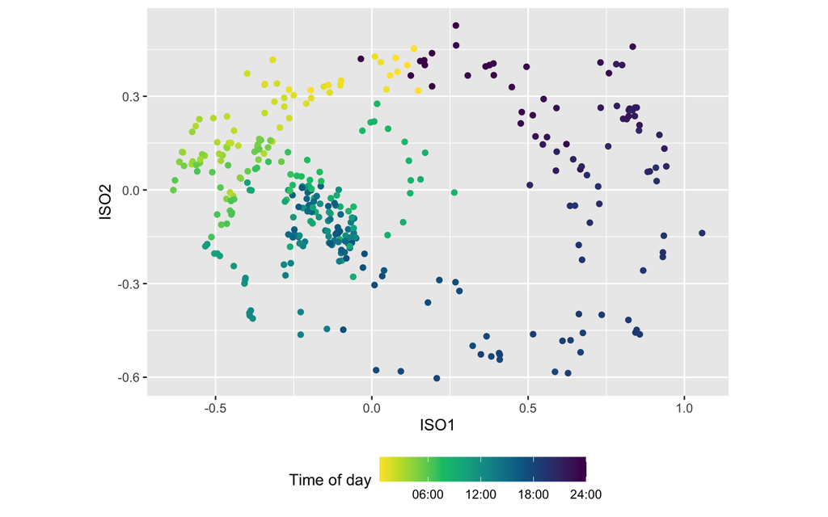

```r
# fn <- metric_isomap$embedding
# head(fn)
# plot(fn, col = viridis::viridis(24), asp = 1)
plot.embedding(metric_isomap) +
  labs(x = "ISO1", y = "ISO2")
```

# Ellipse plot

Using the Riemannian metric for each point as the 2-d covariance matrix and the 2-d embeddings as the centroid to plot an ellipse for each point.

The underlying requirement is that the Riemannian metric needs to be a square positive definite matrix.

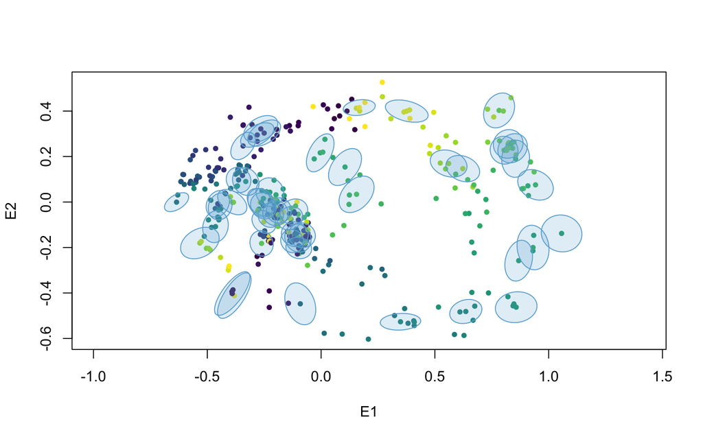

```r
# Done: add argument `n.plot` to specify how many ellipse to be added
# If add = FALSE, fix xlim, ylim, radius for generating ellipse
plot.ellipse <- function(x, n.plot = 50) {
  fn <- x$embedding
  Rn <- x$rmetric
  cols <- viridis::viridis(24)
  n.plot <- 50
  plot(fn, col = cols, asp = 1, pch = 20)
  for (i in sample(1:N, n.plot)) {
    mat <- Rn[,,i]
    center <- c(fn[i,1], fn[i,2])
    add <- T
    car::ellipse(center, mat,
                 radius = .1, # controls the size of ellipse, currently set manually
                 # xlim = c(-.2, .25), ylim = c(-.2, .2),
                 # col = cols[i],
                 col = blues9[5],
                 asp = 1, pty = "s", lwd = 1, center.pch = 19, center.cex = 0,
                 fill = T, fill.alpha = 0.2, grid = T, add = add,
                 )
  }
}
plot.ellipse(metric_isomap)
```

To plot as an ggplot2 object, the exsiting `stat_ellipse` does not work for variable covariance matrix. I tried to modify the code and create `stat_ellipse_cov()` which takes another aesthetic `covmat`. But all points are connected as one path.

Also, `purrr:::pmap_dfc()` does not work correctly, so for loop is currently in use.

```r
fn <- metric_isomap$embedding
Rn <- metric_isomap$rmetric
a <- fn %>%
  as_tibble() %>%
  add_column(covmat = purrr::array_branch(Rn, 3))
a
```

```
## # A tibble: 336 x 3
##         E1      E2 covmat
##      <dbl>   <dbl> <list>
##  1  0.0762  0.423  <dbl [2 × 2]>
##  2 -0.0985  0.350  <dbl [2 × 2]>
##  3 -0.210   0.277  <dbl [2 × 2]>
##  4 -0.294   0.200  <dbl [2 × 2]>
##  5 -0.318   0.155  <dbl [2 × 2]>
##  6 -0.345   0.117  <dbl [2 × 2]>
##  7 -0.444  -0.0192 <dbl [2 × 2]>
##  8 -0.477   0.111  <dbl [2 × 2]>
##  9 -0.366   0.141  <dbl [2 × 2]>
## 10 -0.332   0.136  <dbl [2 × 2]>
## # … with 326 more rows
```

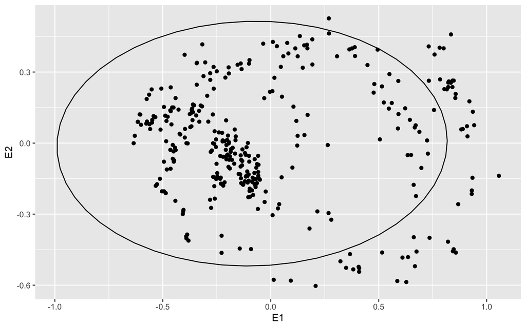

```r
# a$covmat %>% head()

a %>%
  cbind(tod = rep(1:48, N / 48)) %>%
  ggplot(aes(E1, E2)) +
  geom_point() +
  stat_ellipse()
```

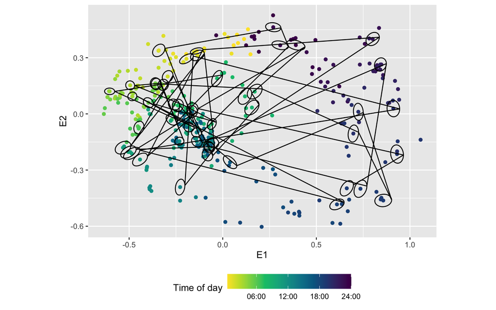

```r
  # stat_ellipse(aes(group = tod, color = tod))

# a %>%
#   cbind(tod = rep(1:48, N / 48)) %>%
#   # group_by(tod) %>%
#   ggplot(aes(x = E1, y = E2, color = tod)) +
#   geom_point() +
#   scale_color_viridis() +
#   stat_ellipse_cov(aes(covmat = covmat))

plot.embedding(x = fn, embedding = T) +
  stat_ellipse_cov(data = cbind(a, tod = rep(1:48, N / 48)), aes(covmat = covmat))
```

# Contour plot

## Variable kernel density estimate

For multivariate data, the variable kernel density estimate is given by
$$\hat{f}(x) = n^{-1} \sum_i K_{H_i} (x - X_i).$$

### Inverse of Riemannian metric as bandwidth matrix

If we use the embedding `x` and the inverse of Riemannian metric `h`, we could produce contour plots based on the density estimates.

```r
emb_isomap <- feather::read_feather(here::here("data/embedding_isomap_1id336tow.feather"))
np <- reticulate::import("numpy")
H_isomap <- np$load(here::here("data/hmatrix_isomap_1id336tow.npy"))
pyh_isomap <- array(NA, dim = c(s, s, N))
for(i in 1:N){
  pyh_isomap[,,i] <- H_isomap[i,,]
}

x <- cbind(emb_isomap$`0`, emb_isomap$`1`)
f <- mkde(x = x, h = pyh_isomap)
summary(f)
```

```
##    Min. 1st Qu.  Median    Mean 3rd Qu.    Max.
##  0.1160  0.2240  0.3087  0.3029  0.3916  0.4828
```

```r
# Top 20 index with the lowest densities
head(order(f), n = 20)
```

```
##  [1]  39 328 327 182 183 136 329 135  40  38 134 278 282 133 326  86 279 231 137
## [20] 281
```

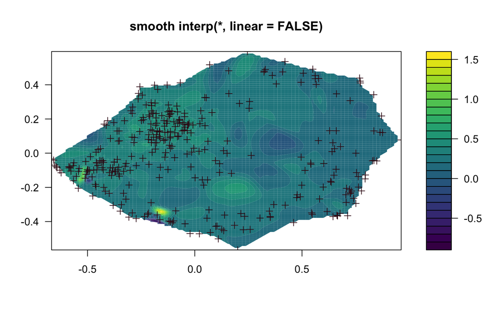

Try linear interpolation using `approx()`.

```r
x_interp <- approx(x[,1], x[,2], n = 100, yleft = 0, yright = 1, ties = mean)
x_int <- cbind(x_interp$x, x_interp$y)
dim(x_int)
f_linerinterp <- mkde(x = x_int, h = pyh_isomap)
f_linerinterp
plot.contour(x_interp, f_linerinterp)
hdrscatterplot(x_interp$x, x_interp$y, noutliers = 10)
p <- filled.contour(akima.spl, color.palette = viridis,
                 plot.axes = { axis(1); axis(2);
                   # title("smooth interp(*, linear = FALSE)");
                   points(embed_den, pch = 3, col= hcl(c=20, l = 10))})
```

Now apply the `mkde()` function to the output of `metricML()` written in R.

```r
x <- metric_isomap$embedding
riem_isomap <- metric_isomap$rmetric
f <- mkde(x = x, h = riem_isomap)
summary(f)
```

```
##    Min. 1st Qu.  Median    Mean 3rd Qu.    Max.
## 0.09451 0.20224 0.30641 0.28375 0.36464 0.47392
```

```r
head(order(f), n=20)
```

```
##  [1]  39 328 327 183 182 135 282 278 329  40 134 136  38 326 231  86 133 281 137
## [20] 279
```

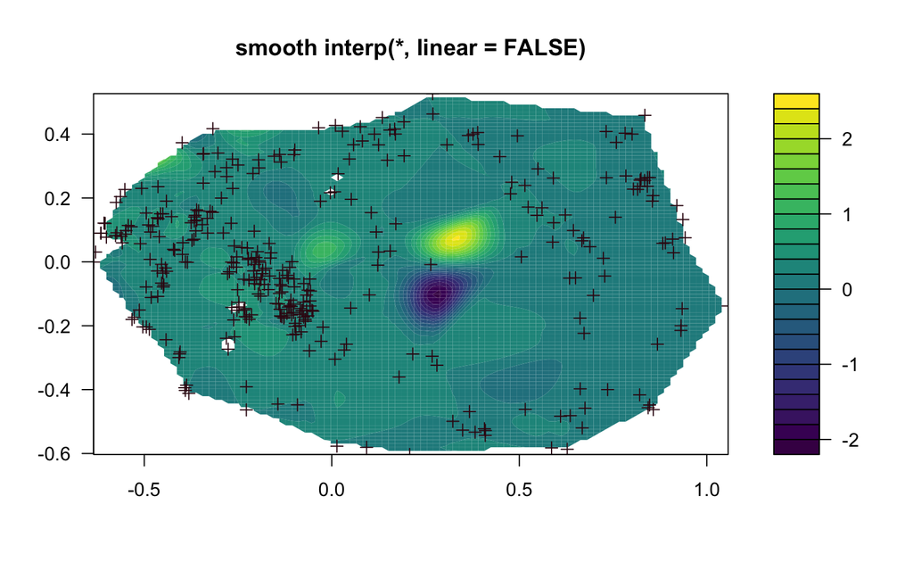

We can check the outliers based on density `f`. In R, the outliers are similar to the `megaman` output.

# t-SNE

```r
method <- "tSNE"
perplexity <- 30
theta <- 0.5
metric_tsne <- metricML(x, s = s, k = k, radius = radius, method = method, annmethod = annmethod, eps = 0, distance = distance, treetype = treetype, searchtype = searchtype, perplexity = perplexity, theta = theta, invert.h = TRUE)
summary(metric_tsne)
```

```
##                Length Class     Mode
## embedding         672 -none-    numeric
## rmetric          1344 -none-    numeric
## weighted_graph     10 igraph    list
## adj_matrix     112896 dgCMatrix S4
## laplacian      112896 dgCMatrix S4
```

```r
f <- mkde(x = metric_tsne$embedding, h = metric_tsne$rmetric)
summary(f)
```

```
##      Min.   1st Qu.    Median      Mean   3rd Qu.      Max.
## 0.0001534 0.0002325 0.0002957 0.0005500 0.0008194 0.0022079
```

```r
head(order(f), n=20)
```

```
##  [1] 211 168 170 123 122 319 313 318 314 316 124 312 315 320 166 214 216  71 260
## [20] 215
```

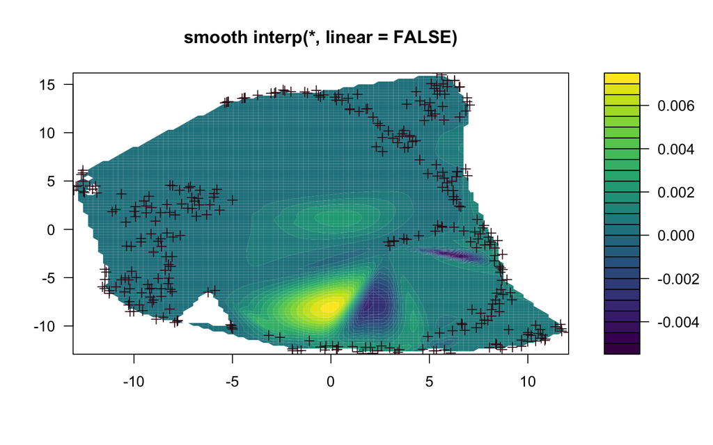

```r
plot.contour(x = metric_tsne$embedding, f, plot.hdr = F)
```